# Churn-Prediction

Shazmin

2024-08-12

## **Introduction**

Hey! Here is my Third project of SQL series “Churn Prediction Analysis”.Today I will go into more deeper and get my hands dirty as much possible. Get ready for a rollercoaster ride through your dataset, as we reveal the mysteries of why customers leave, and use our data science superpowers to predict who might be next. Buckle up, because we’re about to transform a sea of numbers into actionable insights!

## **Dataset Overview**

Our dataset, customer_churn, is a treasure trove of customer interactions and service usage metrics. It includes essential columns such as MonthlyCharges, tenure, and TotalCharges, which provide insights into how much customers are spending, how long they’ve stayed, and their total expenditure over time. The dataset also includes a churn indicator—our golden ticket to understanding customer retention. With this data, we’ll explore patterns, identify trends, and build models to predict which customers are likely to churn, all while giving those numbers a story to tell.You can get the Dataset through this link https://www.kaggle.com/datasets/blastchar/telco-customer-churn.

## **Load Required Libraries**

Install and load the necessary R libraries for data manipulation and visualization:

```r
library(dplyr)
```

```r
library(ggplot2)
library(readr)
library(cluster)
```

## **Load Your Data into R**

Load the CSV files you exported into R:

```r
customer <- read_csv("D:/PROJECTS/SQLProject/Churn-Prediction/Telco-Customer-Churn.csv")
customer_churn <- read_csv("D:/PROJECTS/SQLProject/Churn-Prediction/Telco-Customer-Churn.csv")
```

## **Data Exploration and Preparation**

### Retrieve Basic Information

#### 1.Basic Summary:

```r
summary(customer_churn)
```

```
##   customerID           gender          SeniorCitizen      Partner
##  Length:7043        Length:7043        Min.   :0.0000   Length:7043
##  Class :character   Class :character   1st Qu.:0.0000   Class :character
##  Mode  :character   Mode  :character   Median :0.0000   Mode  :character
##                                        Mean   :0.1621
##                                        3rd Qu.:0.0000
##                                        Max.   :1.0000
##
##   Dependents            tenure      PhoneService       MultipleLines
##  Length:7043        Min.   : 0.00   Length:7043        Length:7043
##  Class :character   1st Qu.: 9.00   Class :character   Class :character
##  Mode  :character   Median :29.00   Mode  :character   Mode  :character
##                     Mean   :32.37
##                     3rd Qu.:55.00
##                     Max.   :72.00
##
##  InternetService    OnlineSecurity     OnlineBackup       DeviceProtection
##  Length:7043        Length:7043        Length:7043        Length:7043
##  Class :character   Class :character   Class :character   Class :character
##  Mode  :character   Mode  :character   Mode  :character   Mode  :character
##
##
##
##
##  TechSupport        StreamingTV        StreamingMovies      Contract
##  Length:7043        Length:7043        Length:7043        Length:7043
##  Class :character   Class :character   Class :character   Class :character
##  Mode  :character   Mode  :character   Mode  :character   Mode  :character
##
##
##
##
##  PaperlessBilling   PaymentMethod      MonthlyCharges    TotalCharges
##  Length:7043        Length:7043        Min.   : 18.25   Min.   :  18.8
##  Class :character   Class :character   1st Qu.: 35.50   1st Qu.: 401.4
##  Mode  :character   Mode  :character   Median : 70.35   Median :1397.5
##                                        Mean   : 64.76   Mean   :2283.3
##                                        3rd Qu.: 89.85   3rd Qu.:3794.7
##                                        Max.   :118.75   Max.   :8684.8
##                                                         NA's   :11
##     Churn
##  Length:7043
##  Class :character
##  Mode  :character
##
##
##
##
```

This is the beauty of summary() function On the other hand in Postgresql how much CTE’s we used to get these result :)

#### 2.Advanced Statistical Summaries:

```r
customer_churn %>%
  group_by(Churn) %>%
  summarise(across(c(MonthlyCharges, tenure, TotalCharges), list(mean = mean, sd = sd, median = median)))
```

```
## # A tibble: 2 × 10
##   Churn MonthlyCharges_mean MonthlyCharges_sd MonthlyCharges_median tenure_mean
##   <chr>               <dbl>             <dbl>                 <dbl>       <dbl>
## 1 No                   61.3              31.1                  64.4        37.6
## 2 Yes                  74.4              24.7                  79.6        18.0
## # ℹ 5 more variables: tenure_sd <dbl>, tenure_median <dbl>,
## #   TotalCharges_mean <dbl>, TotalCharges_sd <dbl>, TotalCharges_median <dbl>
```

#### 3.Visualizations:

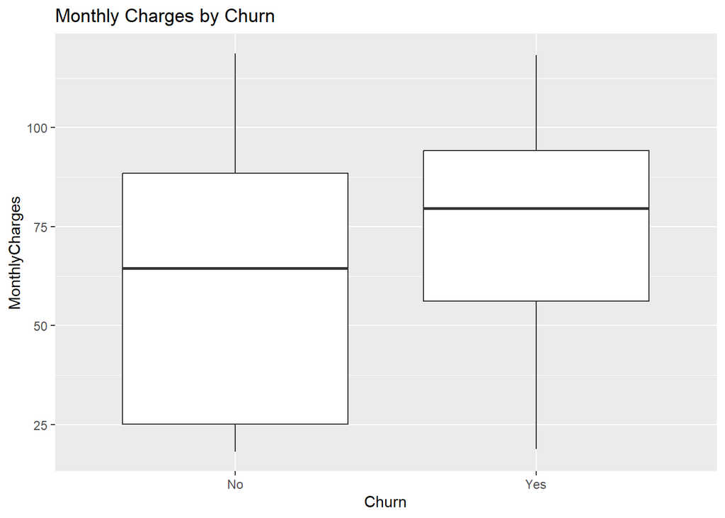

```r
ggplot(customer_churn, aes(x = Churn, y = MonthlyCharges)) + geom_boxplot() + ggtitle("Monthly Charges by Churn")
```

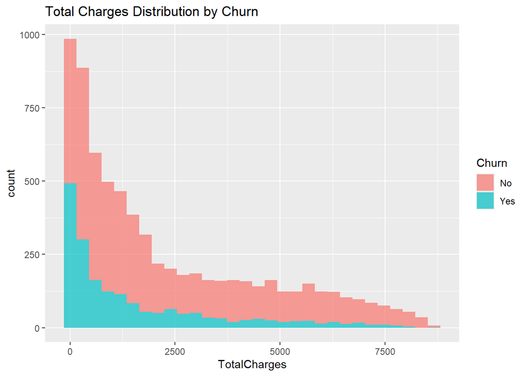

```r
ggplot(customer_churn, aes(x = TotalCharges, fill = Churn)) + geom_histogram(bins = 30, alpha = 0.7) + ggtitle("Total Charges Distribution by Churn")
```

### Examine Customer Demographics:

#### 1.Correlation Analysis:

```r
# Convert Churn to a factor if it's not already
customer_churn$Churn <- as.factor(customer_churn$Churn)

# Create dummy variables
customer_dummies <- model.matrix(~ Churn - 1, data = customer_churn)

#Imputing median in place of NA
customer_churn$TotalCharges[is.na(customer_churn$TotalCharges)] <- median(customer_churn$TotalCharges, na.rm = TRUE)
customer_combined <- cbind(customer_churn[, c("MonthlyCharges", "tenure", "TotalCharges")], customer_dummies)

# Recalculate the correlation matrix
correlation_matrix <- cor(customer_combined)
print(correlation_matrix)
```

```
##                MonthlyCharges     tenure TotalCharges    ChurnNo   ChurnYes
## MonthlyCharges      1.0000000  0.2478999    0.6508643 -0.1933564  0.1933564
## tenure              0.2478999  1.0000000    0.8254641  0.3522287 -0.3522287
## TotalCharges        0.6508643  0.8254641    1.0000000  0.1990368 -0.1990368
## ChurnNo            -0.1933564  0.3522287    0.1990368  1.0000000 -1.0000000
## ChurnYes            0.1933564 -0.3522287   -0.1990368 -1.0000000  1.0000000
```

Here first we have Converted categorical variable ‘Churn’ into dummy variables.model.matrix() creates dummy variables for Churn, where each level of the factor becomes a new column.Then we handled the missing values in ‘TotalCharges’ by imputing median.We see the strong correlation between Total charges and monthly charges, Tenure and Total charges.

#### 2.Regression Analysis:

##### *What is Logistic Regression?*

Logistic Regression is a statistical method used for binary classification problems. It models the probability of a binary outcome based on one or more predictor variables. Unlike linear regression, which predicts continuous values, logistic regression predicts the probability of the target variable belonging to a particular class.

##### *When to Use Logistic Regression*

*Binary Outcomes*: When your outcome variable is binary (e.g., yes/no, 0/1, churn/no churn). *Probability Estimation*: When you need to estimate the probability of a certain event occurring. *Classification Problems*: When you want to classify observations into two categories based on predictor variables.

```r
# Logistic Regression
model <- glm(Churn ~ MonthlyCharges + tenure + TotalCharges, data = customer_churn, family = binomial)
summary(model)
```

```
##
## Call:
## glm(formula = Churn ~ MonthlyCharges + tenure + TotalCharges,
##     family = binomial, data = customer_churn)
##
## Coefficients:
##                  Estimate Std. Error z value Pr(>|z|)
## (Intercept)    -1.655e+00  1.161e-01 -14.259   <2e-16 ***
## MonthlyCharges  3.086e-02  1.705e-03  18.094   <2e-16 ***
## tenure         -6.412e-02  5.310e-03 -12.076   <2e-16 ***
## TotalCharges    1.119e-04  6.006e-05   1.864   0.0623 .
## ---
## Signif. codes:  0 '***' 0.001 '**' 0.01 '*' 0.05 '.' 0.1 ' ' 1
##
## (Dispersion parameter for binomial family taken to be 1)
##
##     Null deviance: 8150.1  on 7042  degrees of freedom
## Residual deviance: 6390.8  on 7039  degrees of freedom
## AIC: 6398.8
##
## Number of Fisher Scoring iterations: 6
```

**MonthlyCharges** and **tenure** have significant effects on the outcome, with higher monthly charges increasing the odds and longer tenure decreasing the odds of the event. **TotalCharges** has a minimal and less significant effect on the outcome.

### Service Usage Overview

#### 1.Visualize Differences:

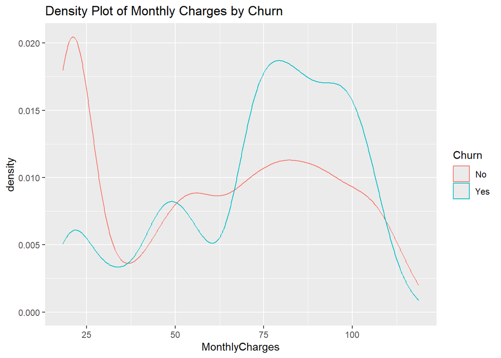

```r
# Density Plot
ggplot(customer_churn, aes(x = MonthlyCharges, color = Churn)) + geom_density() + ggtitle("Density Plot of Monthly Charges by Churn")
```

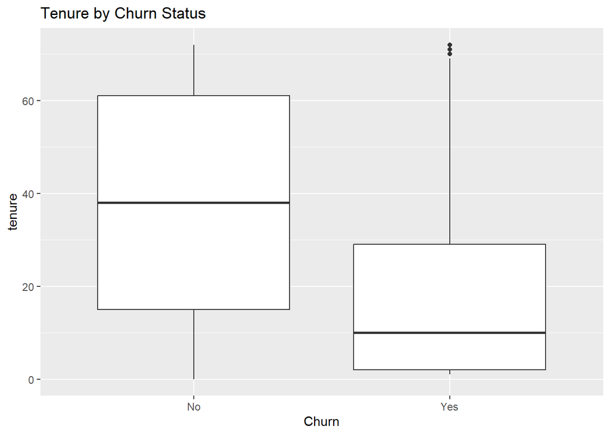

```r
# Boxplot for Tenure
ggplot(customer_churn, aes(x = Churn, y = tenure)) + geom_boxplot() + ggtitle("Tenure by Churn Status")
```

## **2. Data Cleaning and Feature Engineering**

### **Identify and Handle Missing Values**

#### 1.Identify Missing Values:

```r
colSums(is.na(customer))
```

```
##       customerID           gender    SeniorCitizen          Partner
##                0                0                0                0
##       Dependents           tenure     PhoneService    MultipleLines
##                0                0                0                0
##  InternetService   OnlineSecurity     OnlineBackup DeviceProtection
##                0                0                0                0
##      TechSupport      StreamingTV  StreamingMovies         Contract
##                0                0                0                0
## PaperlessBilling    PaymentMethod   MonthlyCharges     TotalCharges
##                0                0                0               11
##            Churn
##                0
```

We have only 11 missing values for Total charges which we handled above by Imputing median.But we can use other advance method as well.let’s see

#### 2.Advance Imputation:

**MICE (Multivariate Imputation by Chained Equations)**is a method used to handle missing data in a dataset. Here’s how it works in simple terms: - *Imputation Process*: It creates multiple versions of your dataset (called “imputations”) by filling in missing values using statistical methods. - *Methods Used*: For each missing value, MICE predicts the value based on other variables in the dataset. In this case, ‘pmm’ (Predictive Mean Matching) is used to estimate missing values. - *Combine Results*: After generating multiple completed datasets, MICE combines them to provide a final dataset where missing values have been filled in

```r
library(mice)
imputed_data <- mice(customer_churn, m = 5, method = 'pmm', seed = 123)
```

[output not shown]

```r
completed_data <- complete(imputed_data)
```

### **Create Derived Features**

#### 1.Example Feature Engineering:

```r
customer_churn <- customer_churn %>%
  mutate(TotalCharges_per_MonthlyCharges = TotalCharges / MonthlyCharges)
```

## **3. Exploratory Data Analysis (EDA)**

### **Analyze Churn by Customer Segments**

#### 1.Clustering:

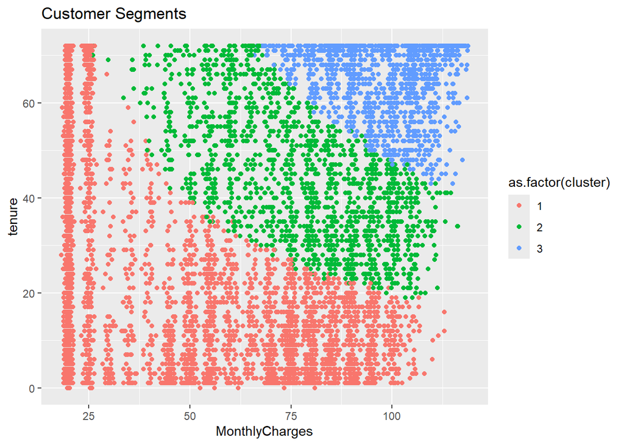

```r
set.seed(123)
clustering <- kmeans(customer_churn[, c("MonthlyCharges", "tenure", "TotalCharges")], centers = 3)
customer_churn$cluster <- clustering$cluster

ggplot(customer_churn, aes(x = MonthlyCharges, y = tenure, color = as.factor(cluster))) + geom_point() + ggtitle("Customer Segments")
```

#### 2.Advanced Visualizations:

```r
library(GGally)
```

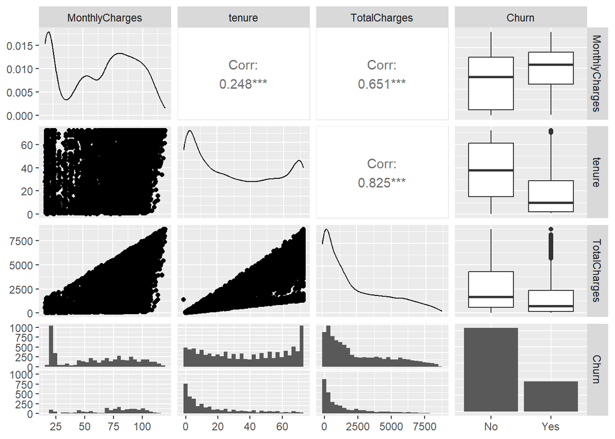

```r
ggpairs(customer_churn, columns = c("MonthlyCharges", "tenure", "TotalCharges", "Churn"))
```

### **Correlation Analysis**

#### 1.Principal Component Analysis (PCA) in Correlation Analysis:

**What is PCA?** PCA (Principal Component Analysis) is a statistical technique used to simplify and reduce the complexity of data while retaining most of its variability. It transforms the original correlated variables into a new set of uncorrelated variables called principal components. These components are ordered so that the first few capture the most variation in the data.

**Why Use PCA?**

-> To identify patterns in the data. -> To reduce dimensionality (i.e., fewer variables) while preserving as much information as possible. -> To visualize high-dimensional data in a lower-dimensional space.

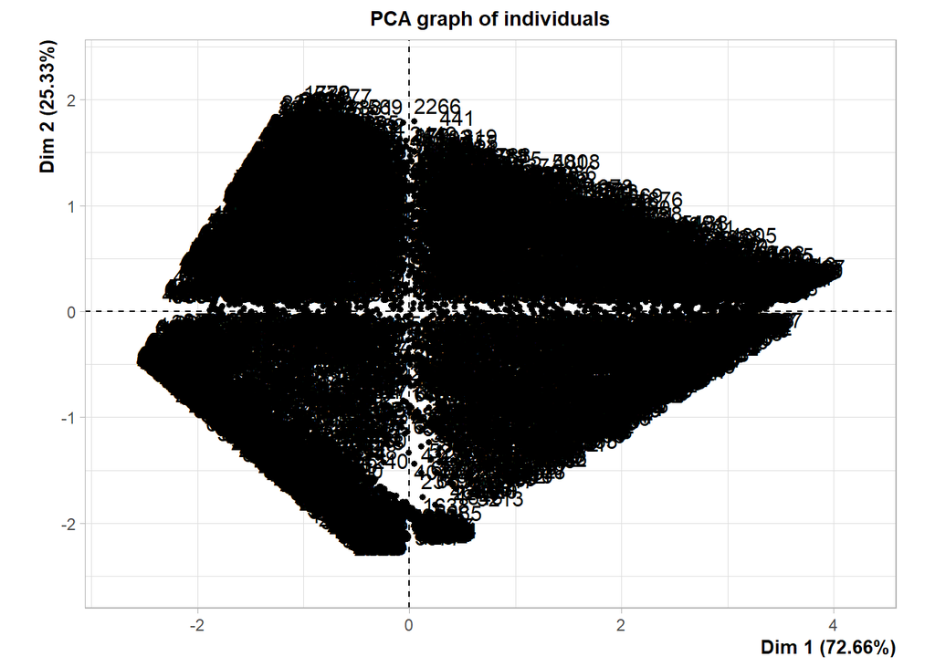

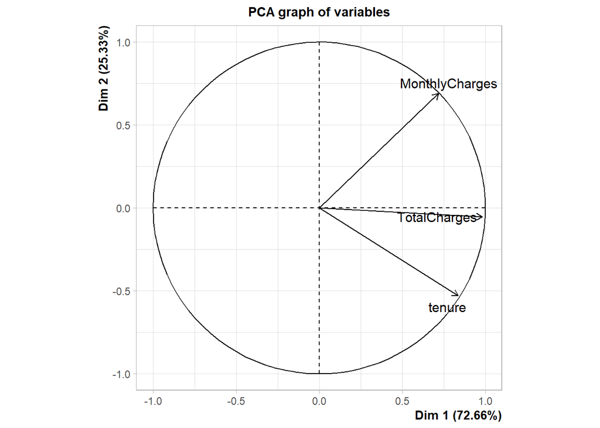

```r
library(FactoMineR)
pca_result <- PCA(customer_churn %>% select(MonthlyCharges, tenure, TotalCharges), scale.unit = TRUE)
```

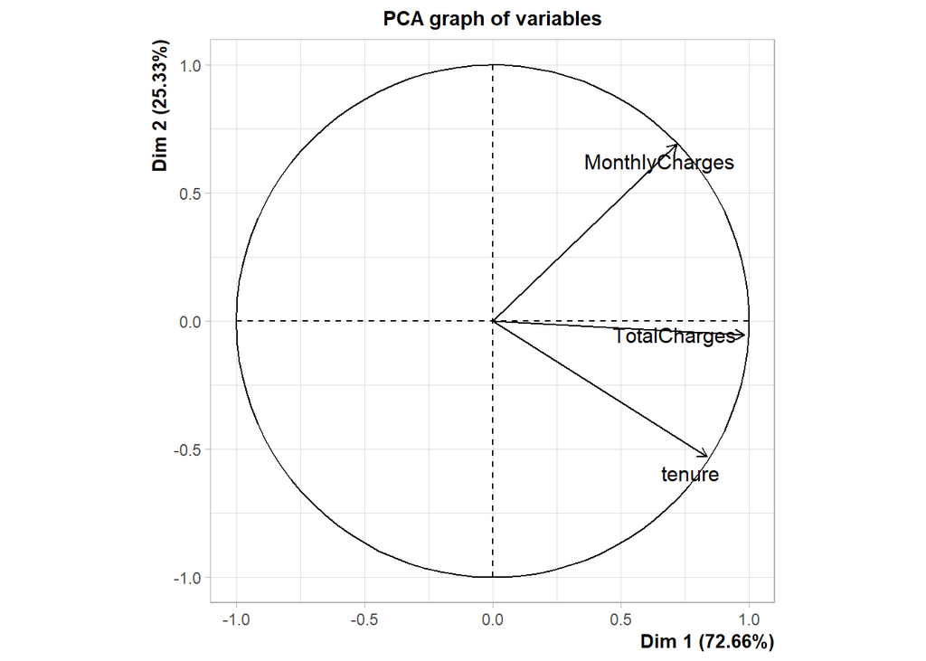

```r
plot(pca_result, choix = "var")
```

Variables that are close together in the plot are more correlated i.e Total Charges and tenure, while variables that are far apart are less correlated.Look at the direction and length of the vectors (arrows) in the plot. Longer vectors indicate variables with higher contributions to the principal components.

#### 2.Factor Analysis:

**What is Factor Analysis?**

Factor Analysis is a statistical technique used to identify underlying relationships between variables. It groups variables that are correlated into factors, which represent a set of underlying dimensions or constructs. This helps in reducing the number of variables by summarizing them into fewer factors, making data analysis easier and more interpretable.

```r
library(psych)
fa_result <- fa(customer_churn %>% select(MonthlyCharges, tenure, TotalCharges), nfactors = 2)
print(fa_result)
```

```
## Factor Analysis using method =  minres
## Call: fa(r = customer_churn %>% select(MonthlyCharges, tenure, TotalCharges),
##     nfactors = 2)
## Standardized loadings (pattern matrix) based upon correlation matrix
##                  MR1   MR2   h2    u2 com
## MonthlyCharges -0.03  0.89 0.77 0.235 1.0
## tenure          1.01 -0.11 0.94 0.064 1.0
## TotalCharges    0.71  0.47 1.00 0.005 1.7
##
##                        MR1  MR2
## SS loadings           1.60 1.10
## Proportion Var        0.53 0.37
## Cumulative Var        0.53 0.90
## Proportion Explained  0.59 0.41
## Cumulative Proportion 0.59 1.00
##
##  With factor correlations of
##      MR1  MR2
## MR1 1.00 0.42
## MR2 0.42 1.00
##
## Mean item complexity =  1.3
## Test of the hypothesis that 2 factors are sufficient.
##
## df null model =  3  with the objective function =  2.3 with Chi Square =  16217.19
## df of  the model are -2  and the objective function was  0
##
## The root mean square of the residuals (RMSR) is  0
## The df corrected root mean square of the residuals is  NA
##
## The harmonic n.obs is  7043 with the empirical chi square  0  with prob <  NA
## The total n.obs was  7043  with Likelihood Chi Square =  0  with prob <  NA
##
## Tucker Lewis Index of factoring reliability =  1
## Fit based upon off diagonal values = 1
## Measures of factor score adequacy
##                                                    MR1  MR2
## Correlation of (regression) scores with factors   0.98 0.96
## Multiple R square of scores with factors          0.97 0.93
## Minimum correlation of possible factor scores     0.94 0.85
```

## **4. Model Building**

### **Prepare Data for Modeling**

#### 1.Split Data:

```r
library(caret)
set.seed(123)
train_index <- createDataPartition(customer_churn$Churn, p = 0.7, list = FALSE)
train_data <- customer_churn[train_index, ]
test_data <- customer_churn[-train_index, ]
train_data$Churn <- as.factor(train_data$Churn)

# Check for missing values in train_data
sum(is.na(train_data))
```

```
## [1] 0
```

```r
train_data <- na.omit(train_data)
```

### **Feature Selection**

#### 1.Recursive Feature Elimination

```r
library(randomForest)
control <- rfeControl(functions = rfFuncs, method = "cv", number = 10)
results <- rfe(train_data %>% select(-Churn), train_data$Churn, sizes = c(1:5), rfeControl = control)
print(results)
```

```
##
## Recursive feature selection
##
## Outer resampling method: Cross-Validated (10 fold)
##
## Resampling performance over subset size:
##
##  Variables Accuracy  Kappa AccuracySD KappaSD Selected
##          1   0.6717 0.1887    0.01680 0.02912
##          2   0.7528 0.2621    0.01086 0.04915
##          3   0.7542 0.2586    0.01092 0.06432
##          4   0.7717 0.3899    0.01826 0.04591
##          5   0.7804 0.4046    0.01356 0.03587
##         22   0.7891 0.4085    0.01730 0.04453        *
##
## The top 5 variables (out of 22):
##    TotalCharges_per_MonthlyCharges, tenure, Contract, MonthlyCharges, TotalCharges
```

### **Build Churn Prediction Model**

#### 1.Logistic Regression:

```r
model_logistic <- glm(Churn ~ MonthlyCharges + tenure + TotalCharges, data = train_data, family = binomial)
summary(model_logistic)
```

```
##
## Call:
## glm(formula = Churn ~ MonthlyCharges + tenure + TotalCharges,
##     family = binomial, data = train_data)
##
## Coefficients:
##                  Estimate Std. Error z value Pr(>|z|)
## (Intercept)    -1.667e+00  1.378e-01 -12.097   <2e-16 ***
## MonthlyCharges  3.088e-02  2.018e-03  15.305   <2e-16 ***
## tenure         -6.636e-02  6.428e-03 -10.322   <2e-16 ***
## TotalCharges    1.402e-04  7.218e-05   1.943    0.052 .
## ---
## Signif. codes:  0 '***' 0.001 '**' 0.01 '*' 0.05 '.' 0.1 ' ' 1
##
## (Dispersion parameter for binomial family taken to be 1)
##
##     Null deviance: 5707.1  on 4930  degrees of freedom
## Residual deviance: 4471.3  on 4927  degrees of freedom
## AIC: 4479.3
##
## Number of Fisher Scoring iterations: 6
```

#### 2.Random Forest:

```r
train_data$Churn <- as.factor(train_data$Churn)
model_rf <- randomForest(Churn ~ MonthlyCharges + tenure + TotalCharges, data = train_data)
print(model_rf)
```

```
##
## Call:
##  randomForest(formula = Churn ~ MonthlyCharges + tenure + TotalCharges,      data = train_data)
##                Type of random forest: classification
##                      Number of trees: 500
## No. of variables tried at each split: 1
##
##         OOB estimate of  error rate: 22.75%
## Confusion matrix:
##       No Yes class.error
## No  3180 442   0.1220320
## Yes  680 629   0.5194805
```

#### 3.Gradient Boosting:

```r
train_data <- train_data %>%
  mutate_if(is.character, as.factor) %>%
  mutate_if(is.factor, as.numeric)

library(xgboost)
dtrain <- xgb.DMatrix(data = as.matrix(train_data %>% select(-Churn)), label = as.numeric(train_data$Churn) - 1)

# Train the XGBoost model
model_xgb <- xgboost(data = dtrain, nrounds = 10, objective = "binary:logistic")
```

### **Evaluate Model Performance**

#### 1.ROC-AUC:

```r
library(pROC)
pred_probs_logistic <- predict(model_logistic, test_data, type = "response")
roc_result_logistic <- roc(test_data$Churn, pred_probs_logistic)
```

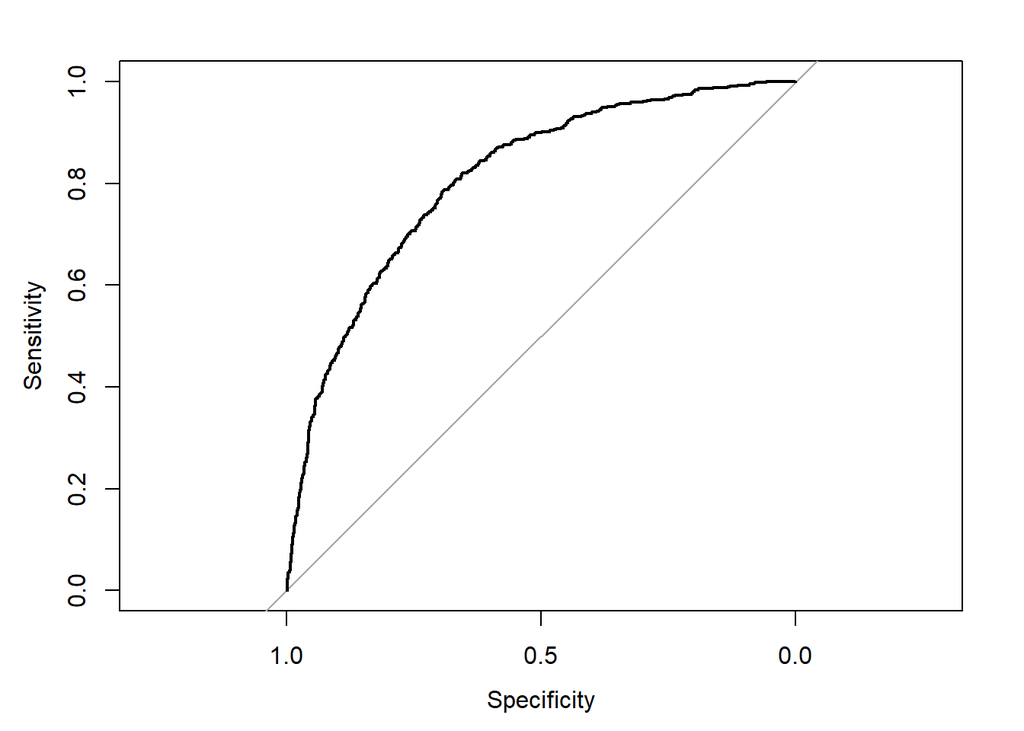

```r
plot(roc_result_logistic)
```

```r
auc(roc_result_logistic)
```

```
## Area under the curve: 0.8087
```

```r
pred_probs_rf <- predict(model_rf, test_data, type = "prob")[, "Yes"]
roc_result_rf <- roc(test_data$Churn, pred_probs_rf)
```

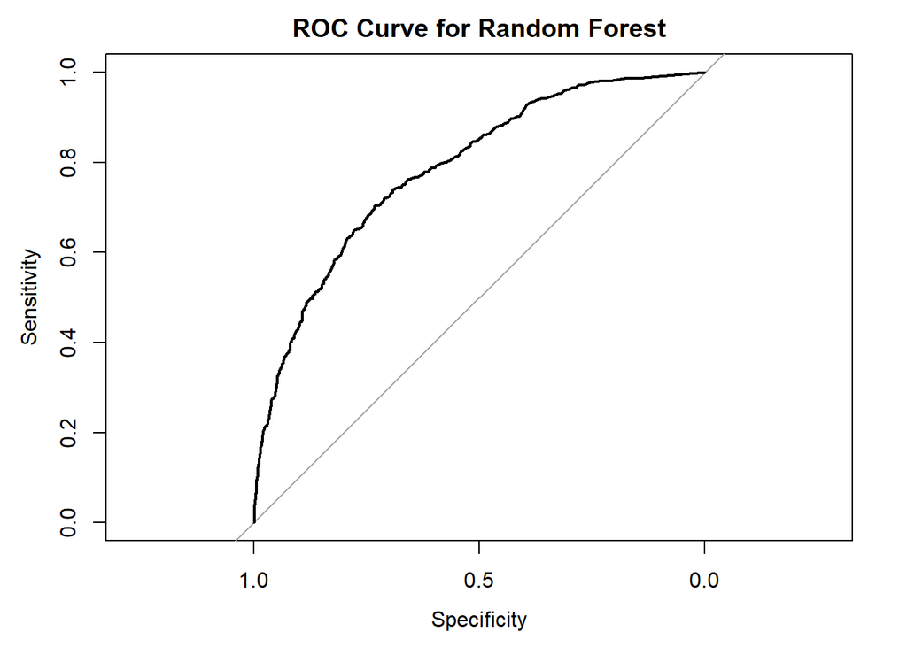

```r
plot(roc_result_rf, main = "ROC Curve for Random Forest")
```

```r
auc(roc_result_rf)
```

```
## Area under the curve: 0.785
```

```r
test_data_numeric <- test_data %>%
  mutate_if(is.character, as.factor) %>%
  mutate_if(is.factor, as.numeric)
dtest <- xgb.DMatrix(data = as.matrix(test_data_numeric %>% select(-Churn)))
pred_probs_xgb <- predict(model_xgb, dtest)

# Evaluate ROC-AUC
library(pROC)
roc_result_xgb <- roc(test_data$Churn, pred_probs_xgb)
```

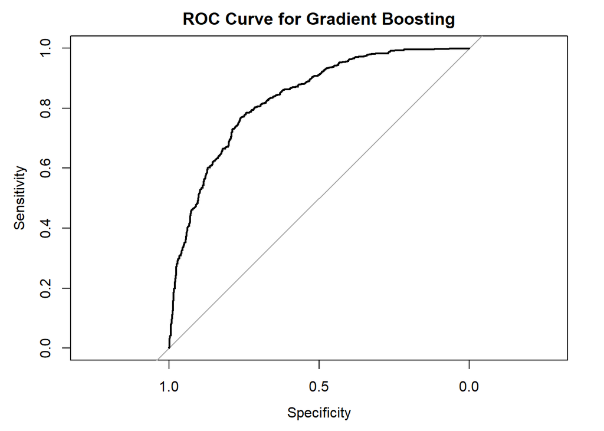

```r
plot(roc_result_xgb, main = "ROC Curve for Gradient Boosting")
```

```r
auc(roc_result_xgb)
```

```
## Area under the curve: 0.8328
```

#### 2.Precision-Recall Curves:

```r
library(PRROC)

# Convert the 'Churn' factor to a numeric vector
churn_numeric <- as.numeric(test_data$Churn == "Yes")  # 1 for "Yes", 0 for "No"

# Ensure that predictions are numeric vectors
scores_class0 <- as.numeric(pred_probs_logistic[churn_numeric == 1])
scores_class1 <- as.numeric(pred_probs_logistic[churn_numeric == 0])

# Check the results
str(scores_class0)
```

```
##  num [1:560] 0.535 0.549 0.671 0.526 0.517 ...
```

```r
str(scores_class1)
```

```
##  num [1:1552] 0.0436 0.4746 0.0277 0.1094 0.1652 ...
```

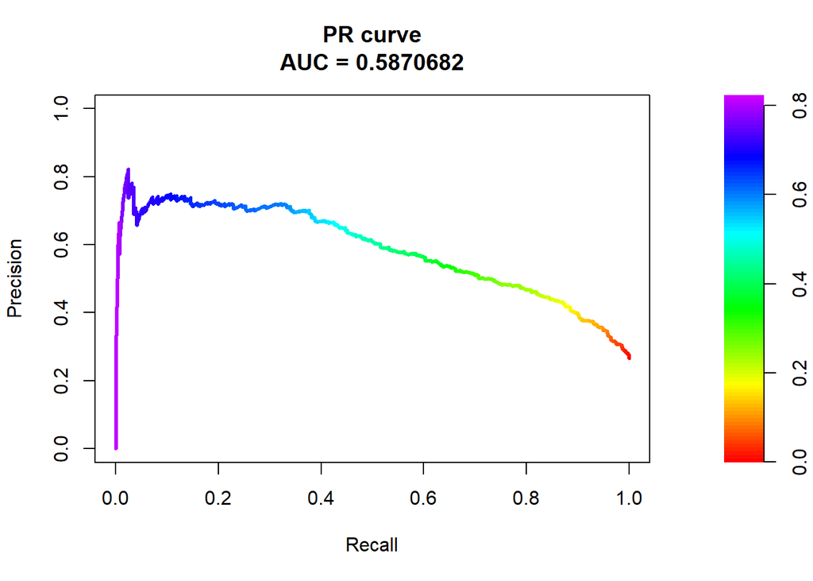

```r
# Generate the precision-recall curve
prroc_result <- pr.curve(scores.class0 = scores_class0,
                         scores.class1 = scores_class1,
                         curve = TRUE)

# Plot the curve
plot(prroc_result)
```

## **5. Visualization and Reporting**

### **Visualize Churn Patterns**

#### 1.Plot:

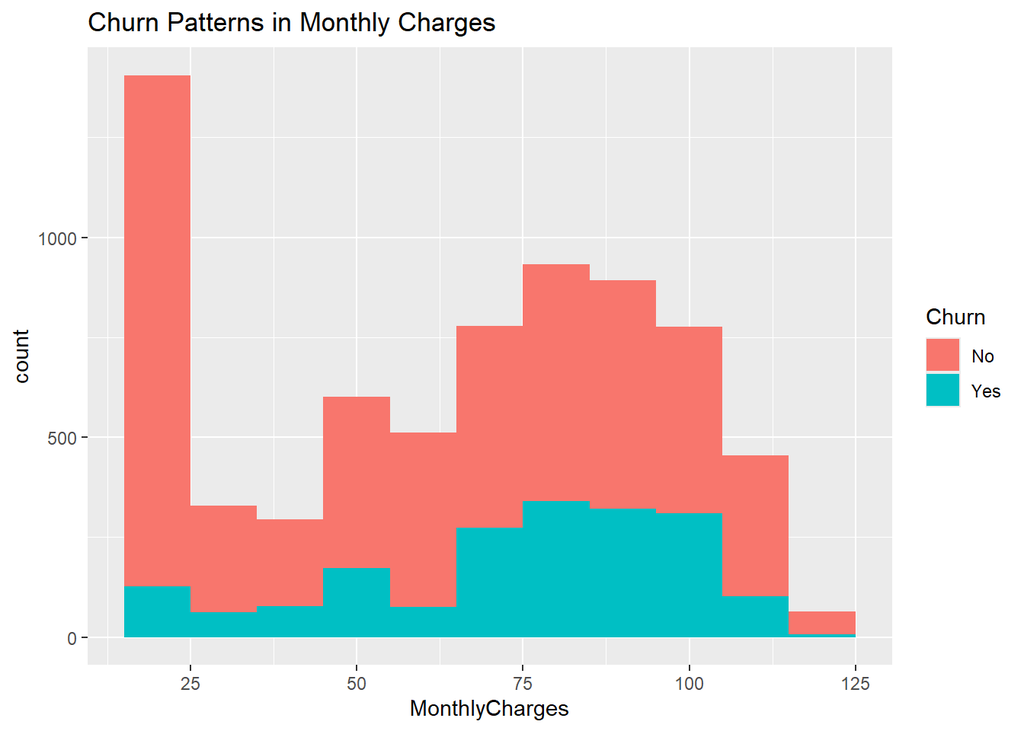

```r
ggplot(customer_churn, aes(x = MonthlyCharges, fill = Churn)) + geom_histogram(binwidth = 10) + ggtitle("Churn Patterns in Monthly Charges")
```

#### 2.Dashboards:

```r
library(shiny)
customer_churn$Churn <- as.factor(customer_churn$Churn)

# Define UI
ui <- fluidPage(
  titlePanel("Churn Analysis"),
  sidebarLayout(
    sidebarPanel(
      # Input for binwidth
      sliderInput("binwidth",
                  "Binwidth for Histogram:",
                  min = 1,
                  max = 50,
                  value = 10)
    ),
    mainPanel(
      plotOutput("churnPlot")
    )
  )
)

# Define server logic
server <- function(input, output) {
  output$churnPlot <- renderPlot({
    ggplot(customer_churn, aes(x = MonthlyCharges, fill = Churn)) +
      geom_histogram(binwidth = input$binwidth) +
      labs(title = "Distribution of Monthly Charges by Churn Status",
           x = "Monthly Charges",
           y = "Count") +
      theme_minimal()
  })
}

# Run the application
shinyApp(ui = ui, server = server)
```

Shiny applications not supported in static R Markdown documents

### Dashboard 2:

```r
# Define UI for application
ui <- fluidPage(
  titlePanel("Churn Analysis Dashboard"),
  sidebarLayout(
    sidebarPanel(
      sliderInput("probRange", "Select Churn Probability Range:",
                  min = 0, max = 1, value = c(0, 1), step = 0.01)
    ),
    mainPanel(
      tabsetPanel(
        tabPanel("Churn Rate Distribution",
                 plotOutput("churnRatePlot")),
        tabPanel("Churn Probability Distribution",
                 plotOutput("probDistPlot"))
      )
    )
  )
)

# Define server logic
server <- function(input, output) {
  # Load the customer churn data
  data <- reactive({
    # Simulate data loading
    customer_churn %>%
      mutate(ChurnProbability = predict(model_logistic, newdata = customer_churn, type = "response")) %>%
      mutate(Churn = as.factor(Churn)) %>%
      filter(ChurnProbability >= input$probRange[1] & ChurnProbability <= input$probRange[2])
  })

  # Churn Rate Distribution Plot
  output$churnRatePlot <- renderPlot({
    ggplot(data(), aes(x = Churn)) +
      geom_bar(fill = "skyblue", color = "black") +
      labs(title = "Distribution of Churn",
           x = "Churn",
           y = "Count") +
      theme_minimal()
  })

  # Churn Probability Distribution Plot
  output$probDistPlot <- renderPlot({
    ggplot(data(), aes(x = ChurnProbability)) +
      geom_histogram(binwidth = 0.05, fill = "skyblue", color = "black") +
      labs(title = "Distribution of Churn Probabilities",
           x = "Churn Probability",
           y = "Frequency") +
      theme_minimal()
  })
}

# Run the application
shinyApp(ui = ui, server = server)
```

Shiny applications not supported in static R Markdown documents

```r
predictions_df <- data.frame(
  Actual = test_data$Churn,
  Predicted_Probabilities = pred_probs_xgb
)


head(predictions_df)
```

```
##   Actual Predicted_Probabilities
## 1     No              0.04250599
## 2     No              0.39997956
## 3    Yes              0.50774574
## 4     No              0.07886373
## 5     No              0.03314655
## 6     No              0.16376027
```